# Who is making more than $50000

```r
library(ggplot2)
library(rpart)
library(e1071)
library(ROCR)
```

```r
df1_train <- read.table(
  "https://archive.ics.uci.edu/ml/machine-learning-databases/adult/adult.data",
  na.strings = '?',header = F,strip.white=T,sep = ',')
names(df1_train) <- c(
  "age","workclass","fnlwgt","education","education_num","marital_status",
  "occupation","relationship","race","sex","capital_gain","capital_loss",
  "hours_per_week","native_country","income")
```

adding new columns:

```r
df1_train$income_binary <- ifelse(df1_train$income=='>50K',1,0)
df1_train$education_num <- as.ordered(df1_train$education_num)
df1_train$income_binary <- as.factor(df1_train$income_binary)
df1_train$education <- factor(df1_train$education,
                            levels = c("Preschool","1st-4th","5th-6th","7th-8th","9th","10th",
                                       "11th","12th","HS-grad","Some-college","Assoc-voc",
                                       "Assoc-acdm","Bachelors","Masters","Prof-school","Doctorate"
                                                                                       ))
df1_train$education <- as.ordered(df1_train$education)
```

removing missing values:

```r
df1_train <- df1_train[complete.cases(df1_train),]
```

summarize the entire data set

```r
str(df1_train)
```

```
'data.frame':   30162 obs. of  16 variables:
 $ age           : int  39 50 38 53 28 37 49 52 31 42 ...
 $ workclass     : Factor w/ 8 levels "Federal-gov",..: 7 6 4 4 4 4 4 6 4 4 ...
 $ fnlwgt        : int  77516 83311 215646 234721 338409 284582 160187 209642 45781 159449 ...
 $ education     : Ord.factor w/ 16 levels "Preschool"<"1st-4th"<..: 13 13 9 7 13 14 5 9 14 13 ...
 $ education_num : Ord.factor w/ 16 levels "1"<"2"<"3"<"4"<..: 13 13 9 7 13 14 5 9 14 13 ...
 $ marital_status: Factor w/ 7 levels "Divorced","Married-AF-spouse",..: 5 3 1 3 3 3 4 3 5 3 ...
 $ occupation    : Factor w/ 14 levels "Adm-clerical",..: 1 4 6 6 10 4 8 4 10 4 ...
 $ relationship  : Factor w/ 6 levels "Husband","Not-in-family",..: 2 1 2 1 6 6 2 1 2 1 ...
 $ race          : Factor w/ 5 levels "Amer-Indian-Eskimo",..: 5 5 5 3 3 5 3 5 5 5 ...
 $ sex           : Factor w/ 2 levels "Female","Male": 2 2 2 2 1 1 1 2 1 2 ...
 $ capital_gain  : int  2174 0 0 0 0 0 0 0 14084 5178 ...
 $ capital_loss  : int  0 0 0 0 0 0 0 0 0 0 ...
 $ hours_per_week: int  40 13 40 40 40 40 16 45 50 40 ...
 $ native_country: Factor w/ 41 levels "Cambodia","Canada",..: 39 39 39 39 5 39 23 39 39 39 ...
 $ income        : Factor w/ 2 levels "<=50K",">50K": 1 1 1 1 1 1 1 2 2 2 ...
 $ income_binary : Factor w/ 2 levels "0","1": 1 1 1 1 1 1 1 2 2 2 ...
```

# Univariate and Bivariate Analysis

Discriptive stats about age

```r
summary(df1_train$age)
```

```
   Min. 1st Qu.  Median    Mean 3rd Qu.    Max.
  17.00   28.00   37.00   38.44   47.00   90.00
```

Lets plot how age is distributed

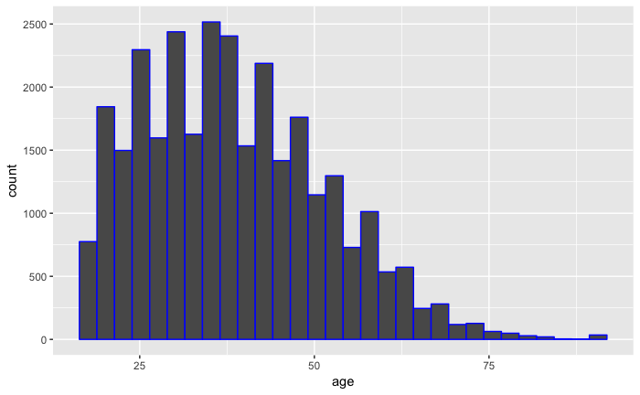

```r
ggplot(df1_train)+
  geom_histogram(mapping = aes(x = age), color = "blue")
```

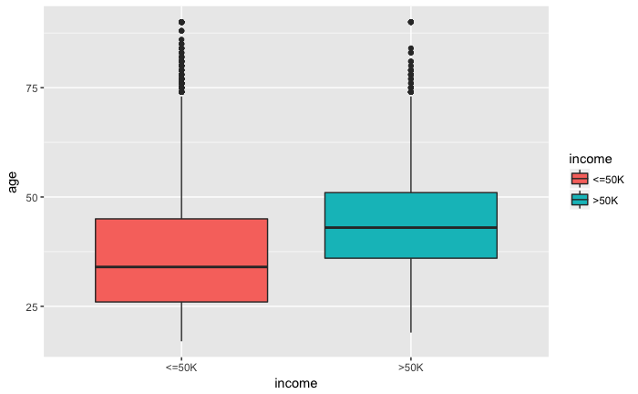

```r
ggplot(data = df1_train)+
  geom_boxplot(mapping = aes( x = income, y = age, fill = income))
```

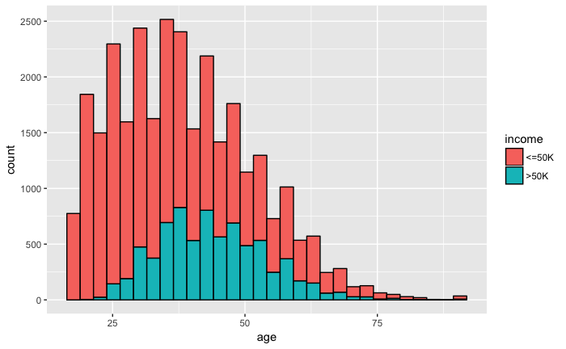

```r
ggplot(df1_train)+
  geom_histogram(mapping = aes(x = age, fill = income),color = "black")
```

This variation of age for income levels clearly indicates that age is going to be an important variable in modelling.

Lets see how income is dependent on education

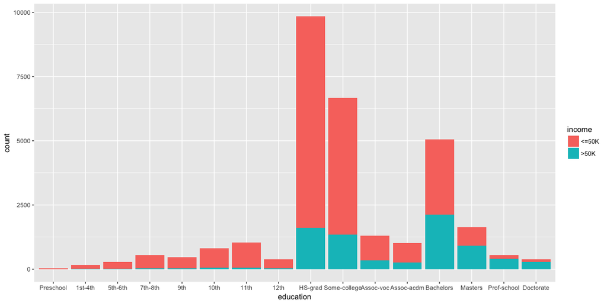

```r
ggplot(data = df1_train)+
  geom_bar(mapping = aes(x = education, fill = income))
```

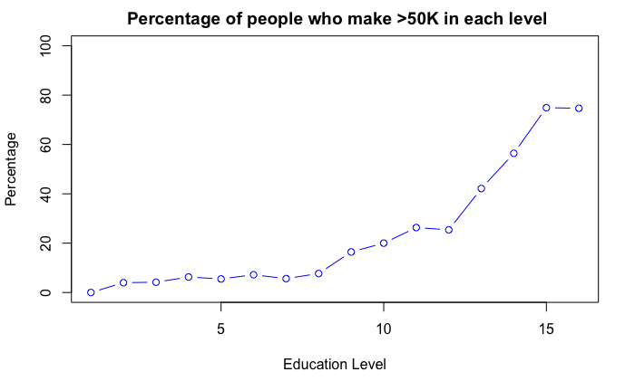

```r
t <- table(df1_train$education, df1_train$income)
PercentMaking50K <- c(1:16)
for(i in 1:16){
  PercentMaking50K[i] <- round(((t[i,2])/(t[i,1]+t[i,2])*100),2)
}
names(PercentMaking50K) <- c("Preschool","1st-4th","5th-6th","7th-8th","9th","10th",
                                       "11th","12th","HS-grad","Some-college","Assoc-voc",
                                       "Assoc-acdm","Bachelors","Masters","Prof-school","Doctorate"
                                                                                       )
plot(PercentMaking50K,type = "b",
     col = "blue",
     main = " Percentage of people who make >50K in each level",
     xlab = "Education Level",
     ylab = "Percentage",
     xlim = c(1,16),
     ylim = c(0,100)
)
```

We can see a clear upward trend which means with increasing education level people have more chance of making more than $50000. So this variable is going to be helpful in modelling in next steps.

Lets explore marital status

```r
summary(df1_train$marital_status)
```

```
             Divorced     Married-AF-spouse    Married-civ-spouse Married-spouse-absent
                 4214                    21                 14065                   370
        Never-married             Separated               Widowed
                 9726                   939                   827
```

Intuitively these are very detailed separtaions. Lets make it more broad definitions.

First we have to convert this factor variable to character type to make changes

```r
df1_train$marital_status <- as.character(df1_train$marital_status)
```

Group1-3

```r
Married <- c("Married-AF-spouse", "Married-civ-spouse", "Married-spouse-absent")
NeverMarried <- c("Never-married")
Separated <- c("Divorced", "Widowed", "Separated")
```

```r
df1_train$marital_status[df1_train$marital_status %in% Married] <- "married"
df1_train$marital_status[df1_train$marital_status %in% Separated] <- "Separated"
df1_train$marital_status <- as.factor(df1_train$marital_status)
```

```r
summary(df1_train$marital_status)
```

```
      married Never-married     Separated
        14456          9726          5980
```

```r
table(df1_train$income, df1_train$marital_status)
```

```
        married Never-married Separated
  <=50K    8016          9256      5382
  >50K     6440           470       598
```

Lets plot barplot to see how income varies across this variable

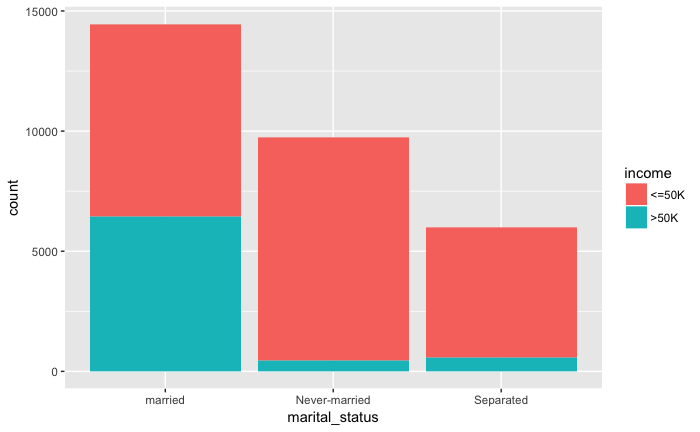

```r
ggplot(data = df1_train)+
  geom_bar(mapping = aes(x = marital_status, fill = income))
```

Clear distinction can be seen.

```r
summary(df1_train$occupation)
```

```
     Adm-clerical      Armed-Forces      Craft-repair   Exec-managerial   Farming-fishing
             3721                 9              4030              3992               989
Handlers-cleaners Machine-op-inspct     Other-service   Priv-house-serv    Prof-specialty
             1350              1966              3212               143              4038
  Protective-serv             Sales      Tech-support  Transport-moving
              644              3584               912              1572
```

Again we see so many levels for this variable just like marital_status. Lets bring these in to smaller groups.

```r
WhiteCollar <- c("Exec-managerial", "Prof-specialty")
BlueCollar <- c("Adm-clerical", "Armed-Forces", "Protective-serv",
                "Tech-support", "Machine-op-inspct", "Handlers-cleaners",
                "Craft-repair", "Transport-moving")
PinkCollar <- c("Farming-fishing", "Other-service", "Priv-house-serv", "Sales")
```

```r
df1_train$occupation <- as.character(df1_train$occupation)
df1_train$occupation[df1_train$occupation %in% WhiteCollar] <- "White_Collar"
df1_train$occupation[df1_train$occupation %in% BlueCollar] <- "Blue_Collar"
df1_train$occupation[df1_train$occupation %in% PinkCollar] <- "Pink_Collar"
df1_train$occupation <- as.factor(df1_train$occupation)
```

```r
summary(df1_train$occupation)
```

```
 Blue_Collar  Pink_Collar White_Collar
       14204         7928         8030
```

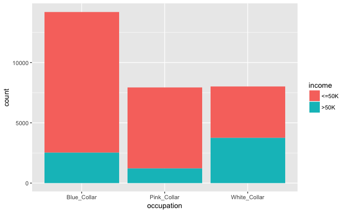

```r
ggplot(data = df1_train)+
  geom_bar(mapping = aes(x = occupation, fill = income))
```

This plot matches my intuition that white collared jobs have more chance of making $50K as they are in managewrial position.

Lets explore relationship variable

```r
summary(df1_train$relationship)
```

```
       Husband  Not-in-family Other-relative      Own-child      Unmarried           Wife
         12463           7726            889           4466           3212           1406
```

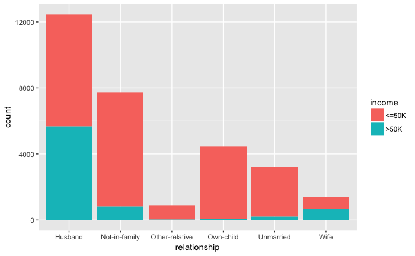

```r
ggplot(data = df1_train)+
  geom_bar(mapping = aes(x = relationship, fill = income))
```

```r
#df1_train$family <- "family"
In_Family <- c("Husband", "Wife", "Own-child")
Not_In_Family <- c("Not-in-family", "Unmarried", "Other-relative")
df1_train$family_relation[df1_train$relationship %in% In_Family] <- "In_Family"
df1_train$family_relation[df1_train$relationship %in% Not_In_Family] <- "Not_In_Family"
df1_train$family_relation <- as.factor(df1_train$family_relation)
```

```r
summary(df1_train$family_relation)
```

```
    In_Family Not_In_Family
        18335         11827
```

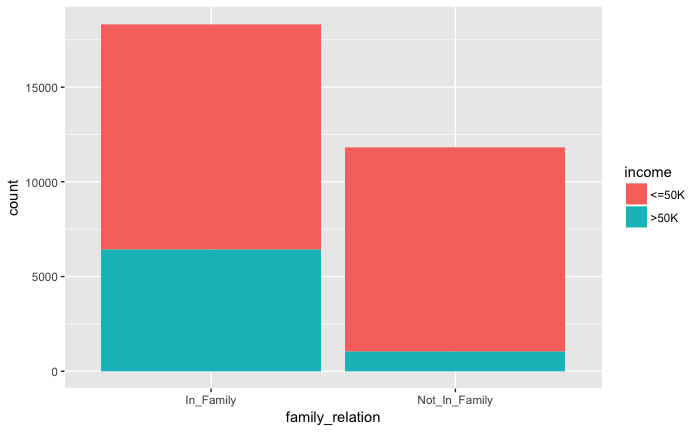

```r
ggplot(data  = df1_train)+
  geom_bar(mapping = aes(x = family_relation, fill = income))
```

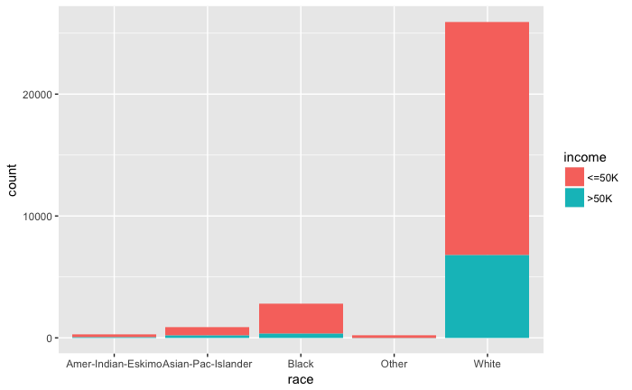

```r
ggplot(data = df1_train)+
  geom_bar(mapping = aes(x = race, fill = income))
```

```r
summary(df1_train$capital_gain)
```

```
   Min. 1st Qu.  Median    Mean 3rd Qu.    Max.
      0       0       0    1092       0  100000
```

```r
summary(df1_train$capital_loss)
```

```
   Min. 1st Qu.  Median    Mean 3rd Qu.    Max.
   0.00    0.00    0.00   88.37    0.00 4356.00
```

Looking at this summary statistic we can see that most of the values are zero. So instead of taking this as a contionus variable I want to consider this as a binary variable and see if it increases the performance of the algorithm.

Adding Some more columns

```r
#cg 1 for those who have some gain
df1_train$capital_gain_binary <- ifelse(df1_train$capital_gain==0,0,1)
df1_train$capital_gain_binary <- as.factor(df1_train$capital_gain_binary)
df1_train$capital_loss_binary <- ifelse(df1_train$capital_loss==0,0,1)
df1_train$capital_loss_binary <- as.factor(df1_train$capital_loss_binary)
#sex binary 1 for male 0 for female
df1_train$sex_binary <- ifelse(df1_train$sex=="Male",1,0)
df1_train$sex_binary <-as.factor(df1_train$sex_binary)
```

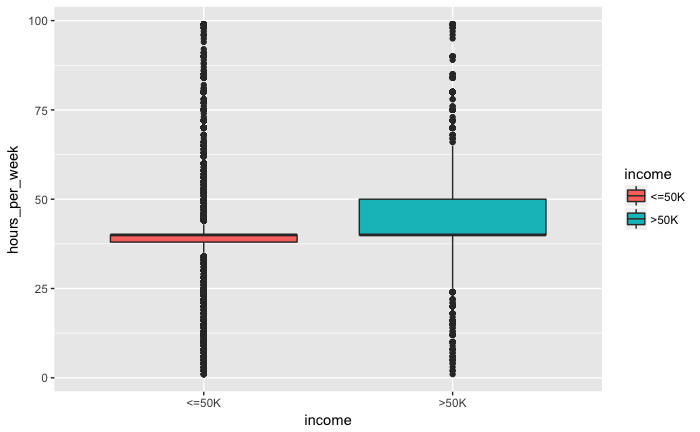

```r
ggplot(data = df1_train)+
  geom_boxplot(mapping = aes(x = income, y = hours_per_week, fill = income))
```

```r
summary(df1_train$native_country)
```

```
                  Cambodia                     Canada                      China
                        18                        107                         68
                  Columbia                       Cuba         Dominican-Republic
                        56                         92                         67
                   Ecuador                El-Salvador                    England
                        27                        100                         86
                    France                    Germany                     Greece
                        27                        128                         29
                 Guatemala                      Haiti         Holand-Netherlands
                        63                         42                          1
                  Honduras                       Hong                    Hungary
                        12                         19                         13
                     India                       Iran                    Ireland
                       100                         42                         24
                     Italy                    Jamaica                      Japan
                        68                         80                         59
                      Laos                     Mexico                  Nicaragua
                        17                        610                         33
Outlying-US(Guam-USVI-etc)                       Peru                Philippines
                        14                         30                        188
                    Poland                   Portugal                Puerto-Rico
                        56                         34                        109
                  Scotland                      South                     Taiwan
                        11                         71                         42
                  Thailand            Trinadad&Tobago              United-States
                        17                         18                      27504
                   Vietnam                 Yugoslavia
                        64                         16
```

```r
length(summary(df1_train$native_country))
```

```
[1] 41
```

As we can see there are people from 41 countries in this data set. Having too many levels in a factor variable is not good for modeling. Hence I created a binary variable which takes the value of 1 for United States and 0 for other countries.

```r
df1_train$united_states <- ifelse(df1_train$native_country=="United-States",1,0)
df1_train$united_states <-as.factor(df1_train$united_states)
```

# Multivariate analysis

Let us explore the relationship between various independent variables

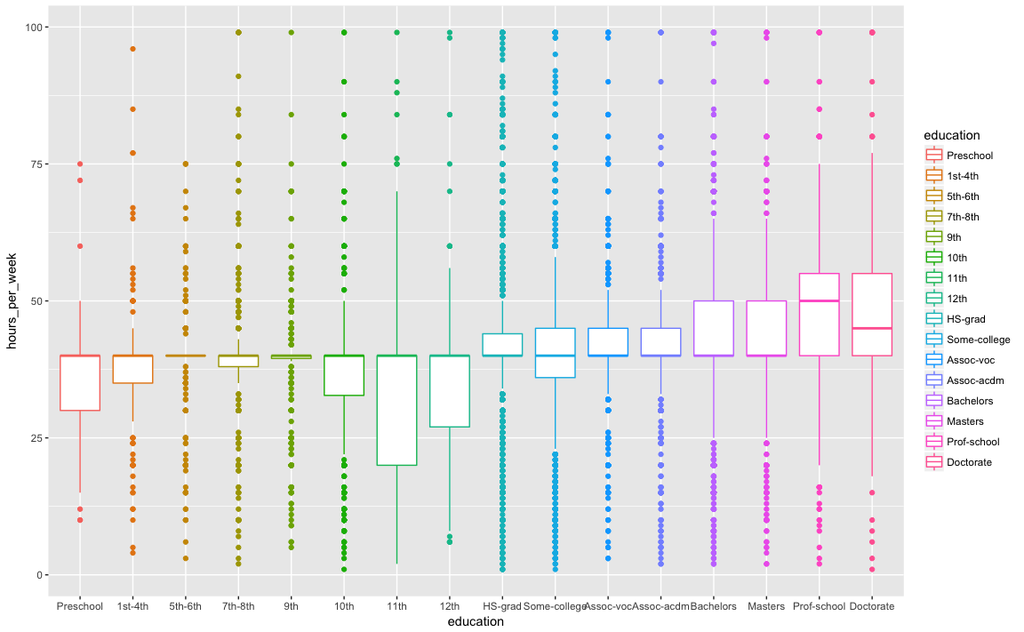

```r
ggplot(data = df1_train)+
  geom_boxplot(mapping = aes(x = education, y = hours_per_week, color = education))
```

```r
NA
```

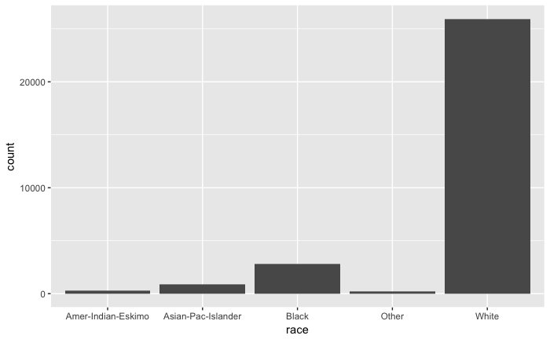

```r
ggplot(data = df1_train)+
  geom_bar(mapping = aes(x = race))
```

Now our data set has 21 variables but some of these variables are just replicates of other variables like capital gain and loss binary variables. We have to make sure we are not using two variables representing the same property while modeling.

# Test Data Cleaning

Before we go in to modeling let us prepare out training data, cross validating data set and test data set. Becuase we made changes to the training set, similar changes must be made to the test data set as well. Lets begin by importing the test data set.

```r
df1_test <- read.table("https://archive.ics.uci.edu/ml/machine-learning-databases/adult/adult.test",na.strings = '?',header = T,strip.white=T,sep = ',',col.names = c("age","workclass","fnlwgt","education","education_num","marital_status","occupation","relationship","race","sex","capital_gain","capital_loss","hours_per_week","native_country","income"))
```

```
header and 'col.names' are of different lengths
```

There was a warning message that col.names are of different lengths. This is because at the URL specified first row had the dimensions of the data set. I ignored that row nby considering it as the header row and later over wrote it by manually giving the column names.

```r
df1_test$education_num <- as.ordered(df1_test$education_num)
df1_test$education <- factor(df1_test$education,
                            levels = c("Preschool","1st-4th","5th-6th","7th-8th","9th","10th",
                                       "11th","12th","HS-grad","Some-college","Assoc-voc",
                                       "Assoc-acdm","Bachelors","Masters","Prof-school","Doctorate"
                                                                                       ))
df1_test$education <- as.ordered(df1_test$education)
#test data has a different way of encoding the income variable with an additional "." followed by 50K
df1_test$income_binary <- ifelse(df1_test$income=='>50K.',1,0)
df1_test$income_binary <- as.factor(df1_test$income_binary)
#remove missing value
df1_test <- df1_test[complete.cases(df1_test), ]
#native country variable
df1_test$united_states <- ifelse(df1_test$native_country=="United-States",1,0)
df1_test$united_states <-as.factor(df1_test$united_states)
#capital gains variable
df1_test$capital_gain_binary <- ifelse(df1_test$capital_gain==0,0,1)
df1_test$capital_gain_binary <- as.factor(df1_test$capital_gain_binary)
#caoital loss variable
df1_test$capital_loss_binary <- ifelse(df1_test$capital_loss==0,0,1)
df1_test$capital_loss_binary <- as.factor(df1_test$capital_loss_binary)
#sex variable
df1_test$sex_binary <- ifelse(df1_test$sex=="Male",1,0)
df1_test$sex_binary <- as.factor(df1_test$sex_binary)
#marital status variable change
df1_test$marital_status <- as.character(df1_test$marital_status)
df1_test$marital_status[df1_test$marital_status %in% Married] <- "married"
df1_test$marital_status[df1_test$marital_status %in% Separated] <- "Separated"
df1_test$marital_status <- as.factor(df1_test$marital_status)
#occupation variable
df1_test$occupation <- as.character(df1_test$occupation)
df1_test$occupation[df1_test$occupation %in% WhiteCollar] <- "White_Collar"
df1_test$occupation[df1_test$occupation %in% BlueCollar] <- "Blue_Collar"
df1_test$occupation[df1_test$occupation %in% PinkCollar] <- "Pink_Collar"
df1_test$occupation <- as.factor(df1_test$occupation)
#relationship variable
df1_test$family_relation[df1_test$relationship %in% In_Family] <- "In_Family"
df1_test$family_relation[df1_test$relationship %in% Not_In_Family] <- "Not_In_Family"
df1_test$family_relation <- as.factor(df1_test$family_relation)
```

Let us export these two data sets.

```r
write.csv(df1_train,file = "Adult_Train_Modified.csv", row.names = F)
write.csv(df1_test,file = "Adult_Test_Modified.csv", row.names = F)
```

# modeling

I want to further divide my training data set in to train and cross validation set. I will use the cross validation set to choose the parameter values of different algorithms I want to use on this data. For this purpose I will randomly sample 25% data in to CV set. Also I will use a seed value so that every time I replicate this code in future I will end up with same cv data set.

```r
train_size <- floor(0.75 * nrow(df1_train))
set.seed(999)
training_index <- sample(nrow(df1_train), size = train_size)
df2_train <- df1_train[training_index, ]
df2_cv <- df1_train[-training_index, ]
df2_cv.Y <- df2_cv[,"income_binary"]
drops <- c("income_binary","income")
df2_cv.X <- df2_cv[ , !(names(df2_cv) %in% drops)]
```

The resulting training data has 22621 rows and cv set has 7541 rows.

# Baseline Metrics

```r
summary(df2_train$income)
```

```
<=50K  >50K
16963  5658
```

```r
19963/(19963+5658)
```

```
[1] 0.7791655
```

## Logistic Regression

Let us use all of the numerical variables and see how our model predicts the outcome.

```r
LR_fit1 <- glm(data = df2_train,
               income_binary ~ age + education_num + capital_gain + capital_loss +
                 hours_per_week, family = "binomial")
```

```
glm.fit: fitted probabilities numerically 0 or 1 occurred
```

There is a warning message that fitted probabilities of 0 0r 1 occured. This indicates that one or the other variables are very strong enough to directly predict the outcome. Let us delete one by one and see which variable is causing this issue.

```r
LR_fit2 <- glm(data = df2_train,
               income_binary ~ age + education_num + capital_gain +
                 hours_per_week, family = "binomial")
```

```
glm.fit: fitted probabilities numerically 0 or 1 occurred
```

```r
LR_fit3 <- glm(data = df2_train,
               income_binary ~ age + education_num + capital_loss +
                 hours_per_week, family = "binomial")
```

```r
LR_fit4 <- glm(data = df2_train, income ~ capital_gain, family = "binomial")
```

```
glm.fit: fitted probabilities numerically 0 or 1 occurred
```

```r
summary(LR_fit4)
```

```
Call:
glm(formula = income ~ capital_gain, family = "binomial", data = df2_train)

Deviance Residuals:
    Min       1Q   Median       3Q      Max
-4.9325  -0.6875  -0.6875   0.0000   1.7654

Coefficients:
               Estimate Std. Error z value Pr(>|z|)
(Intercept)  -1.322e+00  1.686e-02  -78.39   <2e-16 ***
capital_gain  3.265e-04  1.012e-05   32.26   <2e-16 ***
---
Signif. codes:  0 ‘***’ 0.001 ‘**’ 0.01 ‘*’ 0.05 ‘.’ 0.1 ‘ ’ 1

(Dispersion parameter for binomial family taken to be 1)

    Null deviance: 25447  on 22620  degrees of freedom
Residual deviance: 23125  on 22619  degrees of freedom
AIC: 23129

Number of Fisher Scoring iterations: 6
```

So it is the capital_gain variable. What is so special about this variable? Let us again explore this variable. This is the case of linear separation.

```r
LR_fit5 <- glm(data = df2_train,
               income_binary ~ capital_loss + age + education_num + hours_per_week,
               family = "binomial")
```

Because we are going to test different fits let us create a fucntion which will out put the confusiomn matric results for us.

```r
testing_model_performance<- function(fit, testdataX, testdataY, baseprobability){
  predicted_probs <- predict(fit, newdata = testdataX, type = "response")
  prediction_result <- rep(0, length(testdataY))
  prediction_result <- ifelse(predicted_probs > baseprobability, 1, 0)
  t <- table(testdataY, prediction_result)
  accuracy <- (t[1]+t[4])/(length(testdataY))
  true_positive_rate <- (t[4])/(t[2]+t[4]) #sensitivity
  true_negative_rate <- (t[1])/(t[1]+t[3]) #specificity
  precision <- t[4]/(t[3]+t[4])            #positive predictive value
                                     #of all identified as positives how many are actually positive
  recall <- t[4]/(t[2]+t[4])               #of all positives seen how many are correctly identified
  print(t)
  print(paste("Accuracy :",accuracy))

  print(paste("Precision :",precision))

  print(paste("Recall :",recall))

}
```

Let us select those columns from the cv set to test the model

```r
column_list <- c("age", "hours_per_week", "capital_loss", "education_num")
df2_cv.X <- df2_cv[,names(df2_cv) %in% column_list]
df2_cv.Y <- df2_cv$income_binary
```

prediction reults of fit5 using base value of 0.5 as cutoff

```r
testing_model_performance(LR_fit5,df2_cv.X,df2_cv.Y,0.5)
```

```
         prediction_result
testdataY    0    1
        0 5309  382
        1 1204  646
[1] "Accuracy : 0.789683065906378"
[1] "Precision : 0.6284046692607"
[1] "Recall : 0.349189189189189"
```

To improve the accuracy of the model let us keep adding other categorical variables.

adding sex variable to the model:

```r
column_list <- c("age", "hours_per_week", "capital_loss", "education_num", "sex_binary")
df2_cv.X <- df2_cv[,names(df2_cv) %in% column_list]
df2_cv.Y <- df2_cv$income_binary
Model_train_Data <- df2_train[,names(df2_train) %in% column_list]
Model_train_Data$income_binary <- df2_train$income_binary
```

```r
LR_fit6 <- glm(data = Model_train_Data, income_binary ~., family = "binomial")
summary(LR_fit6)
```

```
Call:
glm(formula = income_binary ~ ., family = "binomial", data = Model_train_Data)

Deviance Residuals:
    Min       1Q   Median       3Q      Max
-2.7472  -0.6737  -0.4094   0.1897   3.0171

Coefficients:
                   Estimate Std. Error z value Pr(>|z|)
(Intercept)      -6.629e+00  5.288e+00  -1.254    0.210
age               4.678e-02  1.479e-03  31.630   <2e-16 ***
education_num.L   1.004e+01  3.441e+01   0.292    0.770
education_num.Q  -3.837e+00  3.917e+01  -0.098    0.922
education_num.C   4.089e+00  3.834e+01   0.107    0.915
education_num^4  -3.820e+00  3.367e+01  -0.113    0.910
education_num^5   3.077e+00  2.694e+01   0.114    0.909
education_num^6  -2.685e+00  1.975e+01  -0.136    0.892
education_num^7   1.562e+00  1.327e+01   0.118    0.906
education_num^8  -1.181e+00  8.159e+00  -0.145    0.885
education_num^9   7.894e-01  4.568e+00   0.173    0.863
education_num^10 -1.572e-01  2.314e+00  -0.068    0.946
education_num^11 -1.161e-01  1.054e+00  -0.110    0.912
education_num^12 -1.170e-01  4.450e-01  -0.263    0.793
education_num^13 -4.646e-02  2.159e-01  -0.215    0.830
education_num^14 -1.151e-01  1.437e-01  -0.801    0.423
education_num^15  3.623e-02  1.467e-01   0.247    0.805
capital_loss      5.588e-04  3.954e-05  14.133   <2e-16 ***
hours_per_week    3.273e-02  1.585e-03  20.643   <2e-16 ***
sex_binary1       1.185e+00  4.532e-02  26.154   <2e-16 ***
---
Signif. codes:  0 ‘***’ 0.001 ‘**’ 0.01 ‘*’ 0.05 ‘.’ 0.1 ‘ ’ 1

(Dispersion parameter for binomial family taken to be 1)

    Null deviance: 25447  on 22620  degrees of freedom
Residual deviance: 19552  on 22601  degrees of freedom
AIC: 19592

Number of Fisher Scoring iterations: 12
```

As per this model education is not an importamt variable to predict income.

Let us test this model.

```r
testing_model_performance(LR_fit6,df2_cv.X,df2_cv.Y,0.5)
```

```
         prediction_result
testdataY    0    1
        0 5292  399
        1 1109  741
[1] "Accuracy : 0.800026521681475"
[1] "Precision : 0.65"
[1] "Recall : 0.400540540540541"
```

Accuracy slighly increased to 80%. Let us keep adding other variables as well.

```r
column_list <- c("age", "hours_per_week", "capital_loss", "sex_binary", "workclass")
df2_cv.X <- df2_cv[,names(df2_cv) %in% column_list]
df2_cv.Y <- df2_cv$income_binary
Model_train_Data <- df2_train[,names(df2_train) %in% column_list]
Model_train_Data$income_binary <- df2_train$income_binary
LR_fit7 <- glm(data = Model_train_Data, income_binary ~., family = "binomial")
summary(LR_fit7)
```

```
Call:
glm(formula = income_binary ~ ., family = "binomial", data = Model_train_Data)

Deviance Residuals:
    Min       1Q   Median       3Q      Max
-2.6049  -0.7401  -0.5148   0.2334   2.8117

Coefficients:
                            Estimate Std. Error z value Pr(>|z|)
(Intercept)               -4.721e+00  1.264e-01 -37.349  < 2e-16 ***
age                        4.278e-02  1.356e-03  31.549  < 2e-16 ***
workclassLocal-gov        -3.789e-01  1.006e-01  -3.768 0.000165 ***
workclassPrivate          -6.898e-01  8.407e-02  -8.205 2.31e-16 ***
workclassSelf-emp-inc      5.507e-02  1.126e-01   0.489 0.624855
workclassSelf-emp-not-inc -1.060e+00  9.939e-02 -10.668  < 2e-16 ***
workclassState-gov        -3.735e-01  1.124e-01  -3.323 0.000890 ***
workclassWithout-pay      -1.226e+01  9.240e+01  -0.133 0.894459
capital_loss               6.261e-04  3.687e-05  16.980  < 2e-16 ***
hours_per_week             3.890e-02  1.534e-03  25.354  < 2e-16 ***
sex_binary1                1.069e+00  4.327e-02  24.700  < 2e-16 ***
---
Signif. codes:  0 ‘***’ 0.001 ‘**’ 0.01 ‘*’ 0.05 ‘.’ 0.1 ‘ ’ 1

(Dispersion parameter for binomial family taken to be 1)

    Null deviance: 25447  on 22620  degrees of freedom
Residual deviance: 21779  on 22610  degrees of freedom
AIC: 21801

Number of Fisher Scoring iterations: 11
```

It look slike workclass is an important variable. we have been ignoring this variable since the beginning. Infact it negatively affects the income. Let us test this model accuracy.

```r
testing_model_performance(LR_fit7,df2_cv.X,df2_cv.Y,0.5)
```

```
         prediction_result
testdataY    0    1
        0 5393  298
        1 1419  431
[1] "Accuracy : 0.772311364540512"
[1] "Precision : 0.59122085048011"
[1] "Recall : 0.232972972972973"
```

```r
column_list <- c("age", "hours_per_week", "capital_loss", "sex_binary")
df2_cv.X <- df2_cv[,names(df2_cv) %in% column_list]
df2_cv.Y <- df2_cv$income_binary
Model_train_Data <- df2_train[,names(df2_train) %in% column_list]
Model_train_Data$income_binary <- df2_train$income_binary
LR_fit8 <- glm(data = Model_train_Data, income_binary ~., family = "binomial")
summary(LR_fit8)
```

```
Call:
glm(formula = income_binary ~ ., family = "binomial", data = Model_train_Data)

Deviance Residuals:
    Min       1Q   Median       3Q      Max
-2.6337  -0.7497  -0.5220   0.3243   2.7833

Coefficients:
                 Estimate Std. Error z value Pr(>|z|)
(Intercept)    -5.344e+00  9.503e-02  -56.23   <2e-16 ***
age             4.324e-02  1.318e-03   32.80   <2e-16 ***
capital_loss    6.247e-04  3.651e-05   17.11   <2e-16 ***
hours_per_week  3.885e-02  1.499e-03   25.91   <2e-16 ***
sex_binary1     1.043e+00  4.277e-02   24.39   <2e-16 ***
---
Signif. codes:  0 ‘***’ 0.001 ‘**’ 0.01 ‘*’ 0.05 ‘.’ 0.1 ‘ ’ 1

(Dispersion parameter for binomial family taken to be 1)

    Null deviance: 25447  on 22620  degrees of freedom
Residual deviance: 22022  on 22616  degrees of freedom
AIC: 22032

Number of Fisher Scoring iterations: 5
```

```r
testing_model_performance(LR_fit8,df2_cv.X,df2_cv.Y,0.5)
```

```
         prediction_result
testdataY    0    1
        0 5413  278
        1 1484  366
[1] "Accuracy : 0.766343986208726"
[1] "Precision : 0.56832298136646"
[1] "Recall : 0.197837837837838"
```

Accuracy dropped when we exclude education_num. Hence let us keep it in further analysis.

```r
column_list <- c("age", "hours_per_week", "capital_loss", "sex_binary", "education_num", "workclass")
df2_cv.X <- df2_cv[,names(df2_cv) %in% column_list]
df2_cv.Y <- df2_cv$income_binary
Model_train_Data <- df2_train[,names(df2_train) %in% column_list]
Model_train_Data$income_binary <- df2_train$income_binary
LR_fit9 <- glm(data = Model_train_Data, income_binary ~., family = "binomial")
summary(LR_fit9)
```

```
Call:
glm(formula = income_binary ~ ., family = "binomial", data = Model_train_Data)

Deviance Residuals:
    Min       1Q   Median       3Q      Max
-2.7769  -0.6686  -0.4087   0.1777   3.0141

Coefficients:
                            Estimate Std. Error z value Pr(>|z|)
(Intercept)               -6.304e+00  8.707e+00  -0.724    0.469
age                        4.752e-02  1.519e-03  31.279  < 2e-16 ***
workclassLocal-gov        -4.515e-01  1.075e-01  -4.200 2.66e-05 ***
workclassPrivate          -4.157e-01  8.979e-02  -4.630 3.66e-06 ***
workclassSelf-emp-inc      5.868e-02  1.207e-01   0.486    0.627
workclassSelf-emp-not-inc -9.065e-01  1.060e-01  -8.555  < 2e-16 ***
workclassState-gov        -6.404e-01  1.221e-01  -5.247 1.55e-07 ***
workclassWithout-pay      -1.370e+01  2.525e+02  -0.054    0.957
education_num.L            1.046e+01  5.666e+01   0.185    0.853
education_num.Q           -4.264e+00  6.451e+01  -0.066    0.947
education_num.C            4.600e+00  6.313e+01   0.073    0.942
education_num^4           -4.233e+00  5.545e+01  -0.076    0.939
education_num^5            3.419e+00  4.437e+01   0.077    0.939
education_num^6           -2.933e+00  3.252e+01  -0.090    0.928
education_num^7            1.710e+00  2.185e+01   0.078    0.938
education_num^8           -1.282e+00  1.343e+01  -0.095    0.924
education_num^9            8.591e-01  7.517e+00   0.114    0.909
education_num^10          -2.022e-01  3.800e+00  -0.053    0.958
education_num^11          -7.477e-02  1.719e+00  -0.044    0.965
education_num^12          -1.485e-01  6.959e-01  -0.213    0.831
education_num^13          -2.753e-02  2.806e-01  -0.098    0.922
education_num^14          -1.353e-01  1.518e-01  -0.891    0.373
education_num^15           2.510e-02  1.474e-01   0.170    0.865
capital_loss               5.596e-04  3.974e-05  14.079  < 2e-16 ***
hours_per_week             3.307e-02  1.623e-03  20.376  < 2e-16 ***
sex_binary1                1.201e+00  4.573e-02  26.260  < 2e-16 ***
---
Signif. codes:  0 ‘***’ 0.001 ‘**’ 0.01 ‘*’ 0.05 ‘.’ 0.1 ‘ ’ 1

(Dispersion parameter for binomial family taken to be 1)

    Null deviance: 25447  on 22620  degrees of freedom
Residual deviance: 19414  on 22595  degrees of freedom
AIC: 19466

Number of Fisher Scoring iterations: 13
```

```r
testing_model_performance(LR_fit9,df2_cv.X,df2_cv.Y,0.5)
```

```
         prediction_result
testdataY    0    1
        0 5296  395
        1 1080  770
[1] "Accuracy : 0.804402599124785"
[1] "Precision : 0.660944206008584"
[1] "Recall : 0.416216216216216"
```

```r
column_list <- c("age", "hours_per_week", "capital_loss", "sex_binary", "education_num", "race")
df2_cv.X <- df2_cv[,names(df2_cv) %in% column_list]
df2_cv.Y <- df2_cv$income_binary
Model_train_Data <- df2_train[,names(df2_train) %in% column_list]
Model_train_Data$income_binary <- df2_train$income_binary
LR_fit10 <- glm(data = Model_train_Data, income_binary ~., family = "binomial")
summary(LR_fit10)
```

```
Call:
glm(formula = income_binary ~ ., family = "binomial", data = Model_train_Data)

Deviance Residuals:
    Min       1Q   Median       3Q      Max
-2.7463  -0.6711  -0.4075   0.1897   3.0329

Coefficients:
                         Estimate Std. Error z value Pr(>|z|)
(Intercept)            -6.969e+00  5.336e+00  -1.306   0.1915
age                     4.646e-02  1.479e-03  31.423   <2e-16 ***
education_num.L         9.958e+00  3.469e+01   0.287   0.7741
education_num.Q        -3.814e+00  3.949e+01  -0.097   0.9231
education_num.C         4.065e+00  3.865e+01   0.105   0.9162
education_num^4        -3.787e+00  3.395e+01  -0.112   0.9112
education_num^5         3.056e+00  2.716e+01   0.113   0.9104
education_num^6        -2.679e+00  1.991e+01  -0.135   0.8930
education_num^7         1.574e+00  1.338e+01   0.118   0.9064
education_num^8        -1.194e+00  8.226e+00  -0.145   0.8846
education_num^9         7.940e-01  4.606e+00   0.172   0.8631
education_num^10       -1.661e-01  2.332e+00  -0.071   0.9432
education_num^11       -1.167e-01  1.062e+00  -0.110   0.9125
education_num^12       -1.058e-01  4.481e-01  -0.236   0.8134
education_num^13       -5.178e-02  2.168e-01  -0.239   0.8112
education_num^14       -1.154e-01  1.439e-01  -0.802   0.4227
education_num^15        4.805e-02  1.470e-01   0.327   0.7438
raceAsian-Pac-Islander  3.247e-01  2.456e-01   1.322   0.1862
raceBlack               5.616e-02  2.343e-01   0.240   0.8105
raceOther              -2.420e-01  3.654e-01  -0.662   0.5079
raceWhite               4.377e-01  2.240e-01   1.954   0.0507 .
capital_loss            5.553e-04  3.953e-05  14.049   <2e-16 ***
hours_per_week          3.233e-02  1.585e-03  20.397   <2e-16 ***
sex_binary1             1.163e+00  4.552e-02  25.555   <2e-16 ***
---
Signif. codes:  0 ‘***’ 0.001 ‘**’ 0.01 ‘*’ 0.05 ‘.’ 0.1 ‘ ’ 1

(Dispersion parameter for binomial family taken to be 1)

    Null deviance: 25447  on 22620  degrees of freedom
Residual deviance: 19514  on 22597  degrees of freedom
AIC: 19562

Number of Fisher Scoring iterations: 12
```

```r
testing_model_performance(LR_fit10,df2_cv.X,df2_cv.Y,0.5)
```

```
         prediction_result
testdataY    0    1
        0 5285  406
        1 1104  746
[1] "Accuracy : 0.799761304866729"
[1] "Precision : 0.647569444444444"
[1] "Recall : 0.403243243243243"
```

```r
column_list <- c("age", "hours_per_week", "capital_loss", "sex_binary", "education_num", "united_states")
df2_cv.X <- df2_cv[,names(df2_cv) %in% column_list]
df2_cv.Y <- df2_cv$income_binary
Model_train_Data <- df2_train[,names(df2_train) %in% column_list]
Model_train_Data$income_binary <- df2_train$income_binary
LR_fit11 <- glm(data = Model_train_Data, income_binary ~., family = "binomial")
summary(LR_fit11)
```

```
Call:
glm(formula = income_binary ~ ., family = "binomial", data = Model_train_Data)

Deviance Residuals:
    Min       1Q   Median       3Q      Max
-2.7538  -0.6733  -0.4105   0.1879   3.0540

Coefficients:
                   Estimate Std. Error z value Pr(>|z|)
(Intercept)      -6.810e+00  5.305e+00  -1.284 0.199290
age               4.666e-02  1.479e-03  31.544  < 2e-16 ***
education_num.L   9.905e+00  3.452e+01   0.287 0.774146
education_num.Q  -3.706e+00  3.930e+01  -0.094 0.924874
education_num.C   4.052e+00  3.846e+01   0.105 0.916103
education_num^4  -3.810e+00  3.378e+01  -0.113 0.910196
education_num^5   3.104e+00  2.703e+01   0.115 0.908576
education_num^6  -2.712e+00  1.981e+01  -0.137 0.891136
education_num^7   1.580e+00  1.331e+01   0.119 0.905539
education_num^8  -1.171e+00  8.185e+00  -0.143 0.886206
education_num^9   7.759e-01  4.583e+00   0.169 0.865560
education_num^10 -1.482e-01  2.321e+00  -0.064 0.949074
education_num^11 -1.283e-01  1.057e+00  -0.121 0.903434
education_num^12 -9.416e-02  4.463e-01  -0.211 0.832906
education_num^13 -6.740e-02  2.164e-01  -0.311 0.755460
education_num^14 -1.087e-01  1.438e-01  -0.756 0.449680
education_num^15  4.358e-02  1.467e-01   0.297 0.766371
capital_loss      5.582e-04  3.953e-05  14.120  < 2e-16 ***
hours_per_week    3.260e-02  1.586e-03  20.550  < 2e-16 ***
sex_binary1       1.185e+00  4.534e-02  26.134  < 2e-16 ***
united_states1    2.378e-01  7.180e-02   3.311 0.000928 ***
---
Signif. codes:  0 ‘***’ 0.001 ‘**’ 0.01 ‘*’ 0.05 ‘.’ 0.1 ‘ ’ 1

(Dispersion parameter for binomial family taken to be 1)

    Null deviance: 25447  on 22620  degrees of freedom
Residual deviance: 19540  on 22600  degrees of freedom
AIC: 19582

Number of Fisher Scoring iterations: 12
```

```r
testing_model_performance(LR_fit11,df2_cv.X,df2_cv.Y,0.5)
```

```
         prediction_result
testdataY    0    1
        0 5291  400
        1 1108  742
[1] "Accuracy : 0.800026521681475"
[1] "Precision : 0.649737302977233"
[1] "Recall : 0.401081081081081"
```

```r
column_list <- c("age", "hours_per_week", "capital_loss", "sex_binary", "education_num", "united_states", "family_relation")
df2_cv.X <- df2_cv[,names(df2_cv) %in% column_list]
df2_cv.Y <- df2_cv$income_binary
Model_train_Data <- df2_train[,names(df2_train) %in% column_list]
Model_train_Data$income_binary <- df2_train$income_binary
LR_fit12 <- glm(data = Model_train_Data, income_binary ~., family = "binomial")
summary(LR_fit12)
```

```
Call:
glm(formula = income_binary ~ ., family = "binomial", data = Model_train_Data)

Deviance Residuals:
    Min       1Q   Median       3Q      Max
-2.9509  -0.6211  -0.3302   0.1433   3.4542

Coefficients:
                               Estimate Std. Error z value Pr(>|z|)
(Intercept)                  -5.951e+00  8.387e+00  -0.710 0.477967
age                           4.780e-02  1.549e-03  30.869  < 2e-16 ***
education_num.L               1.047e+01  5.458e+01   0.192 0.847849
education_num.Q              -3.848e+00  6.214e+01  -0.062 0.950621
education_num.C               4.365e+00  6.082e+01   0.072 0.942787
education_num^4              -4.125e+00  5.341e+01  -0.077 0.938444
education_num^5               3.386e+00  4.274e+01   0.079 0.936861
education_num^6              -2.982e+00  3.133e+01  -0.095 0.924164
education_num^7               1.824e+00  2.105e+01   0.087 0.930952
education_num^8              -1.283e+00  1.294e+01  -0.099 0.921042
education_num^9               8.359e-01  7.241e+00   0.115 0.908100
education_num^10             -1.239e-01  3.661e+00  -0.034 0.973006
education_num^11             -1.627e-01  1.657e+00  -0.098 0.921783
education_num^12             -5.282e-02  6.728e-01  -0.078 0.937434
education_num^13             -8.697e-02  2.759e-01  -0.315 0.752642
education_num^14             -1.241e-01  1.531e-01  -0.811 0.417595
education_num^15              6.192e-02  1.494e-01   0.415 0.678504
capital_loss                  5.651e-04  4.153e-05  13.609  < 2e-16 ***
hours_per_week                3.489e-02  1.661e-03  21.007  < 2e-16 ***
family_relationNot_In_Family -1.789e+00  4.967e-02 -36.021  < 2e-16 ***
sex_binary1                   4.565e-01  5.039e-02   9.059  < 2e-16 ***
united_states1                2.661e-01  7.576e-02   3.513 0.000443 ***
---
Signif. codes:  0 ‘***’ 0.001 ‘**’ 0.01 ‘*’ 0.05 ‘.’ 0.1 ‘ ’ 1

(Dispersion parameter for binomial family taken to be 1)

    Null deviance: 25447  on 22620  degrees of freedom
Residual deviance: 17977  on 22599  degrees of freedom
AIC: 18021

Number of Fisher Scoring iterations: 13
```

```r
testing_model_performance(LR_fit12,df2_cv.X,df2_cv.Y,0.5)
```

```
         prediction_result
testdataY    0    1
        0 5260  431
        1  974  876
[1] "Accuracy : 0.813685187640896"
[1] "Precision : 0.670237184391737"
[1] "Recall : 0.473513513513514"
```

```r
column_list <- c("age", "hours_per_week", "capital_loss", "sex_binary", "education_num", "united_states", "family_relation", "race", "workclass", "occupation" ,"marital_status")
df2_cv.X <- df2_cv[,names(df2_cv) %in% column_list]
df2_cv.Y <- df2_cv$income_binary
Model_train_Data <- df2_train[,names(df2_train) %in% column_list]
Model_train_Data$income_binary <- df2_train$income_binary
LR_fit13 <- glm(data = Model_train_Data, income_binary ~., family = "binomial")
summary(LR_fit13)
```

```
Call:
glm(formula = income_binary ~ ., family = "binomial", data = Model_train_Data)

Deviance Residuals:
    Min       1Q   Median       3Q      Max
-2.9306  -0.5856  -0.2484   0.1544   3.5740

Coefficients:
                               Estimate Std. Error z value Pr(>|z|)
(Intercept)                  -4.609e+00  8.149e+00  -0.566   0.5716
age                           2.971e-02  1.797e-03  16.528  < 2e-16 ***
workclassLocal-gov           -6.712e-01  1.185e-01  -5.664 1.48e-08 ***
workclassPrivate             -4.658e-01  9.976e-02  -4.669 3.02e-06 ***
workclassSelf-emp-inc        -1.426e-01  1.335e-01  -1.068   0.2855
workclassSelf-emp-not-inc    -1.047e+00  1.171e-01  -8.939  < 2e-16 ***
workclassState-gov           -8.408e-01  1.342e-01  -6.266 3.69e-10 ***
workclassWithout-pay         -1.397e+01  2.524e+02  -0.055   0.9559
education_num.L               9.736e+00  5.300e+01   0.184   0.8543
education_num.Q              -4.099e+00  6.034e+01  -0.068   0.9458
education_num.C               4.467e+00  5.906e+01   0.076   0.9397
education_num^4              -4.057e+00  5.187e+01  -0.078   0.9377
education_num^5               3.424e+00  4.150e+01   0.082   0.9343
education_num^6              -2.984e+00  3.042e+01  -0.098   0.9219
education_num^7               1.822e+00  2.044e+01   0.089   0.9290
education_num^8              -1.249e+00  1.257e+01  -0.099   0.9208
education_num^9               7.987e-01  7.032e+00   0.114   0.9096
education_num^10             -2.063e-01  3.556e+00  -0.058   0.9537
education_num^11             -1.039e-01  1.609e+00  -0.065   0.9485
education_num^12             -1.256e-01  6.549e-01  -0.192   0.8479
education_num^13             -5.787e-02  2.720e-01  -0.213   0.8315
education_num^14             -1.207e-01  1.540e-01  -0.784   0.4332
education_num^15              1.035e-01  1.537e-01   0.673   0.5008
marital_statusNever-married  -2.561e+00  9.527e-02 -26.877  < 2e-16 ***
marital_statusSeparated      -2.004e+00  1.041e-01 -19.252  < 2e-16 ***
occupationPink_Collar        -2.362e-01  5.497e-02  -4.296 1.74e-05 ***
occupationWhite_Collar        6.438e-01  5.143e-02  12.518  < 2e-16 ***
raceAsian-Pac-Islander        4.875e-01  2.723e-01   1.790   0.0734 .
raceBlack                     2.365e-01  2.517e-01   0.940   0.3473
raceOther                    -2.679e-01  3.911e-01  -0.685   0.4933
raceWhite                     4.126e-01  2.406e-01   1.715   0.0864 .
capital_loss                  5.428e-04  4.344e-05  12.494  < 2e-16 ***
hours_per_week                2.838e-02  1.791e-03  15.847  < 2e-16 ***
family_relationNot_In_Family -2.798e-02  9.255e-02  -0.302   0.7624
sex_binary1                   2.539e-01  5.569e-02   4.559 5.13e-06 ***
united_states1                4.199e-01  8.844e-02   4.748 2.05e-06 ***
---
Signif. codes:  0 ‘***’ 0.001 ‘**’ 0.01 ‘*’ 0.05 ‘.’ 0.1 ‘ ’ 1

(Dispersion parameter for binomial family taken to be 1)

    Null deviance: 25447  on 22620  degrees of freedom
Residual deviance: 16512  on 22585  degrees of freedom
AIC: 16584

Number of Fisher Scoring iterations: 13
```

```r
testing_model_performance(LR_fit13,df2_cv.X,df2_cv.Y,0.5)
```

```
         prediction_result
testdataY    0    1
        0 5223  468
        1  878  972
[1] "Accuracy : 0.821509083675905"
[1] "Precision : 0.675"
[1] "Recall : 0.525405405405405"
```

```r
testing_model_performance(LR_fit13,df2_cv.X,df2_cv.Y,0.2)
```

```
         prediction_result
testdataY    0    1
        0 4001 1690
        1  242 1608
[1] "Accuracy : 0.743800556955311"
[1] "Precision : 0.487568223165555"
[1] "Recall : 0.869189189189189"
```

```r
testing_model_performance(LR_fit13,df2_cv.X,df2_cv.Y,0.3)
```

```
         prediction_result
testdataY    0    1
        0 4544 1147
        1  432 1418
[1] "Accuracy : 0.79061132475799"
[1] "Precision : 0.552826510721248"
[1] "Recall : 0.766486486486487"
```

```r
testing_model_performance(LR_fit13,df2_cv.X,df2_cv.Y,0.4)
```

```
         prediction_result
testdataY    0    1
        0 4960  731
        1  656 1194
[1] "Accuracy : 0.816072138973611"
[1] "Precision : 0.62025974025974"
[1] "Recall : 0.645405405405405"
```

```r
testing_model_performance(LR_fit13,df2_cv.X,df2_cv.Y,0.5)
```

```
         prediction_result
testdataY    0    1
        0 5223  468
        1  878  972
[1] "Accuracy : 0.821509083675905"
[1] "Precision : 0.675"
[1] "Recall : 0.525405405405405"
```

```r
testing_model_performance(LR_fit13,df2_cv.X,df2_cv.Y,0.6)
```

```
         prediction_result
testdataY    0    1
        0 5402  289
        1 1065  785
[1] "Accuracy : 0.820448216416921"
[1] "Precision : 0.730912476722533"
[1] "Recall : 0.424324324324324"
```

```r
testing_model_performance(LR_fit13,df2_cv.X,df2_cv.Y,0.7)
```

```
         prediction_result
testdataY    0    1
        0 5517  174
        1 1237  613
[1] "Accuracy : 0.812889537196658"
[1] "Precision : 0.778907242693774"
[1] "Recall : 0.331351351351351"
```

# Error Rate for unseen test data

```r
column_list <- c("age", "hours_per_week", "capital_loss", "sex_binary", "education_num", "united_states", "family_relation", "race", "workclass", "occupation" ,"marital_status")
df1_test.X <- df1_test[,names(df1_test) %in% column_list]
df1_test.Y <- df1_test$income_binary
testing_model_performance(LR_fit13,df1_test.X,df1_test.Y,0.5)
```

```
         prediction_result
testdataY     0     1
        0 10491   869
        1  1709  1991
[1] "Accuracy : 0.828818061088977"
[1] "Precision : 0.696153846153846"
[1] "Recall : 0.538108108108108"
```

```r
length(df1_test.Y)
```

[output not shown]

```r
summary(df1_test.Y)
```

[output not shown]

```r
11360/(11360+3700)
```

[output not shown]

```r
library(nnet)
nnet.fit = nnet(income_binary~., data=Model_train_Data,size=10,maxit=10000,decay=.001)
```

[output not shown]

```r
nnet.preds = predict(nnet.fit,newdata=df2_cv.X,type="raw")
```

```r
library(ROCR)
#nnet_pred = prediction(nnet.preds,df2_cv.Y)
#nnet_perf = performance(nnet.pred,"tpr","fpr")
```

```r
# plot(nnet.perf,lwd=2,col="blue",main="ROC - Neural Network on Adult")
# abline(a=0,b=1)
```

```r
table(df1_test.Y,predict(nnet.fit,newdata=df1_test.X,type="class"))
```

[output not shown]

```r
1101/(1101+749)
```

[output not shown]

```r
(5125+1101)/(5125+566+749+1101)
```

[output not shown]

Let us try support vector machines

```r
#install.packages("e1071")
library(e1071)
```

```r
# svm.model <- svm(Type ~ ., data = trainset, cost = 100, gamma = 1)
# > svm.pred <- predict(svm.model, testset[,-10])
```

```r
#svm_fit1 <- svm(income_binary ~., data = Model_train_Data, cost = 100, gamma = 1,probability=TRUE)
```

```r
# svm_pred <- predict(svm_fit1, df1_test.X, probability = T)
#
# svm_preds <- prediction(svm_pred, df1_test.Y)
# svm_perf <- performance(svm_preds,"tpr","fpr" )
#table(df2_cv.Y, svm_pred)
```

decison tree

```r
#install.packages("rpart")
library(rpart)
```

```r
# LR_fit13 <- glm(data = Model_train_Data, income_binary ~., family = "binomial")
#
# LR_pred <- predict(LR_fit13, newdata = df2_cv.X, type = "response")
#
# LR_preds <- prediction(LR_pred,df2_cv.Y)
# LR_perf <- performance(LR_preds,"tpr","fpr")

tree_fit1 <- rpart(income_binary ~ ., data = Model_train_Data)
tree_pred <- predict(tree_fit1, df1_test.X, type = "prob")[,2]
tree_preds <- prediction(tree_pred,df1_test.Y)
#table(df2_cv.Y, tree_pred)
```

```r
LR_pred <- predict(LR_fit13, newdata = df1_test.X, type = "response")

LR_preds <- prediction(LR_pred,df1_test.Y)
LR_perf <- performance(LR_preds,"tpr","fpr")
```

```r
tree_perf <- performance(tree_preds,"tpr","fpr")
#svm_perf <- performance(svm_pred,"tpr","fpr")
#nnet_perf <- performance(nnet_pred,"tpr","fpr")
LR_perf <- performance(LR_preds,"tpr","fpr")
```